# MDS

Przemysłam Biecek, Anna Wróblewska

12 January 2017

## Isometric scaling

PCA is very popular, but it is not the only method that can be used for dimension reduction. Other, very popular one, is the Kruskal’s non-metric multidimensional scaling.

There are few interesting and important differences.

- As an input we will use distance matrix not original data. Thus we can use this method even if we are working with non numerical data (e.g. documents). All we need is to define dissimilarity
- Solution is calculated through numerical optimization, sometimes it can be unstable.
- The new coordinated are derived in such a way, that the overall stress is minimized, where stress is defined as the sum of squared differences between the original and transformed dataset (but other definitions of stress are also valid).

https://en.wikipedia.org/wiki/Multidimensional_scaling

https://jonlefcheck.net/2012/10/24/nmds-tutorial-in-r/

### Basic example

Let us start with an example

Sammon scaling - the sum of squared differences between the initial distances and obtained ones, weighted by the distances

```r
library(MASS)
head(USArrests)
```

```
##            Murder Assault UrbanPop Rape
## Alabama      13.2     236       58 21.2
## Alaska       10.0     263       48 44.5
## Arizona       8.1     294       80 31.0
## Arkansas      8.8     190       50 19.5
## California    9.0     276       91 40.6
## Colorado      7.9     204       78 38.7
```

```r
distances <- dist(scale(USArrests))

USArrests <- unique(USArrests)
distances <- distances+0.01

mds <- sammon(distances, k=2)
```

```
## Initial stress        : 0.02649
## stress after  10 iters: 0.01493, magic = 0.461
## stress after  20 iters: 0.01391, magic = 0.500
## stress after  30 iters: 0.01389, magic = 0.500
```

```r
str(mds)
```

```
## List of 3
##  $ points: num [1:50, 1:2] -0.889 -2.88 -1.979 0.173 -2.58 ...
##   ..- attr(*, "dimnames")=List of 2
##   .. ..$ : chr [1:50] "Alabama" "Alaska" "Arizona" "Arkansas" ...
##   .. ..$ : NULL
##  $ stress: num 0.0139
##  $ call  : language sammon(d = distances, k = 2)
```

```r
clusters <- kmeans(USArrests, 10)
mds.clusters <- sammon(dist(clusters$centers), k=2)
```

```
## Initial stress        : 0.00006
## stress after  10 iters: 0.00003, magic = 0.500
```

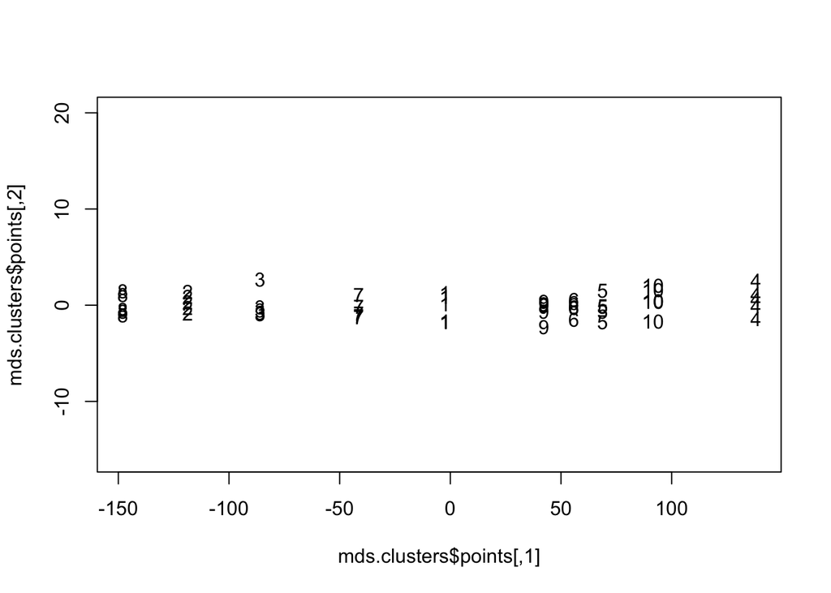

```r
plot(mds.clusters$points, pch=19, col="white")
text(mds.clusters$points[,1], mds$points[,2], 1:10)
```

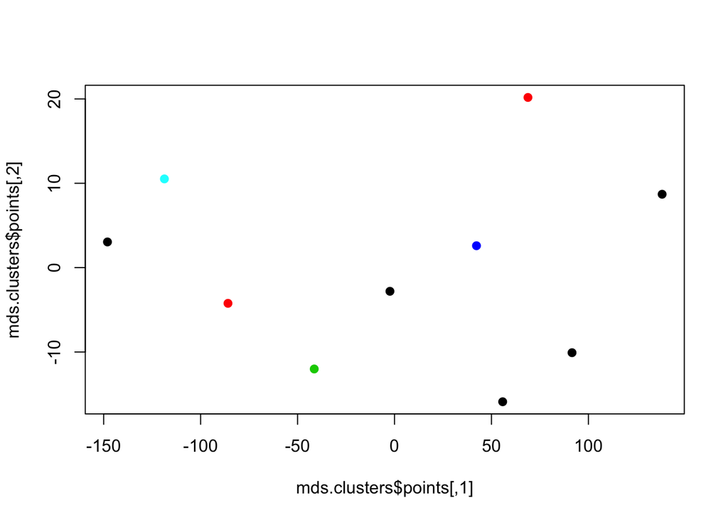

```r
plot(mds.clusters$points, pch=19, col=clusters$cluster)
```

We can then see some diagnostics

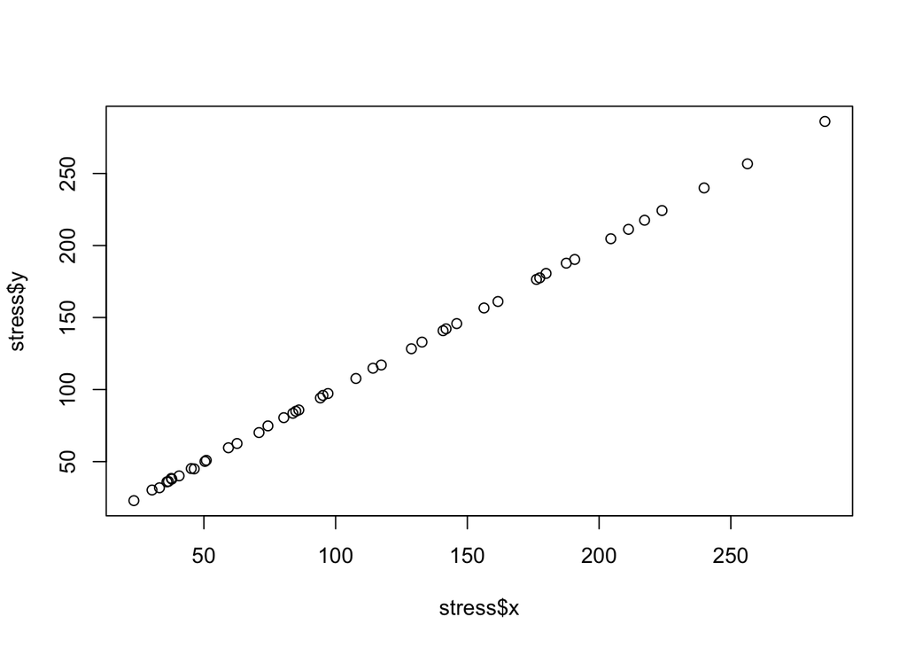

```r
stress <- Shepard(dist(clusters$centers), mds.clusters$points)
plot(stress)
```

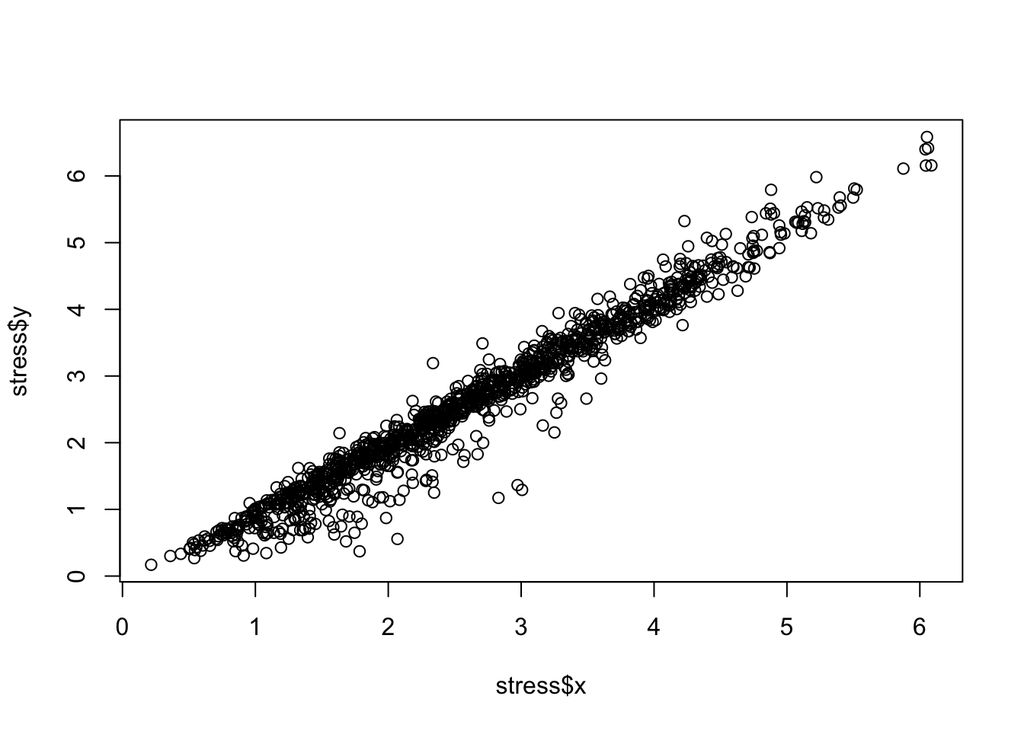

```r
stress <- Shepard(distances, mds$points)
plot(stress)
```

Kruskal scaling - different objective, square root of the ratio of squared difference between distances divided by squares of initial distances.

```r
mds2 <- isoMDS(distances, k=2)
str(mds2)
```

```
## List of 2
##  $ points: num [1:50, 1:2] -0.857 -2.73 -1.753 0.182 -2.507 ...
##   ..- attr(*, "dimnames")=List of 2
##   .. ..$ : chr [1:50] "Alabama" "Alaska" "Arizona" "Arkansas" ...
##   .. ..$ : NULL
##  $ stress: num 7.91
```

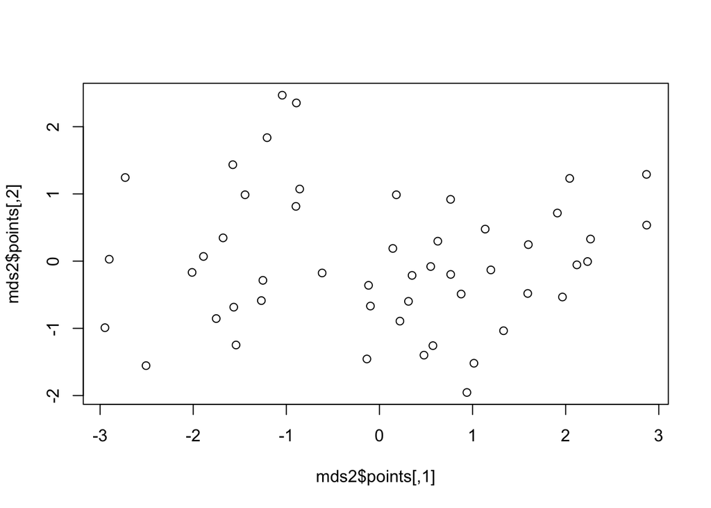

```r
plot(mds2$points)
```

We can then see some diagnostics

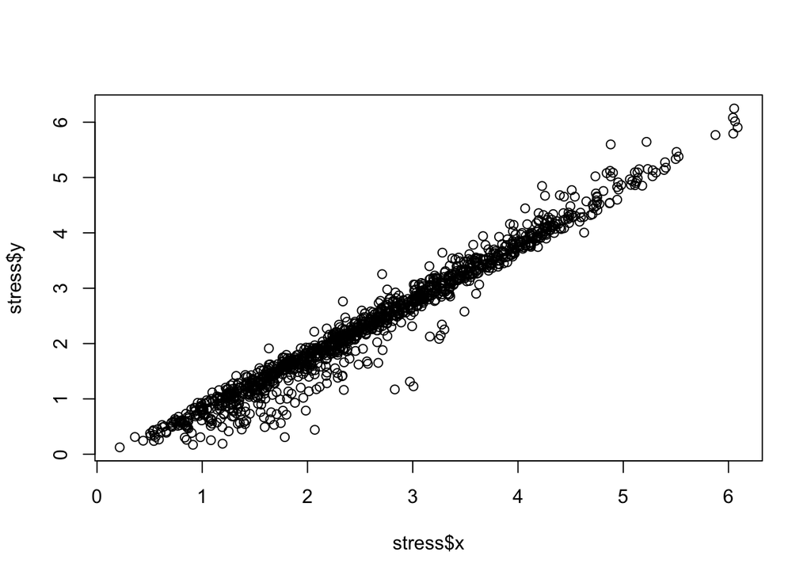

```r
stress <- Shepard(distances, mds2$points)
plot(stress)
```

Another simple example for different scaling algorithms

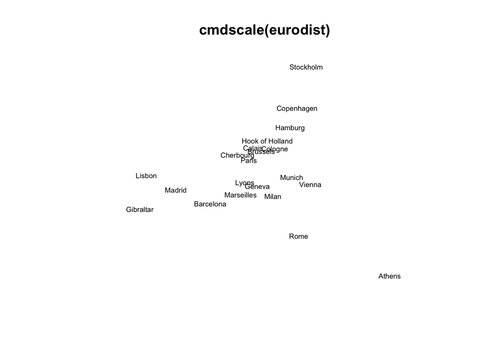

```r
library(graphics)
loc <- cmdscale(eurodist)
x <- loc[, 1]
y <- -loc[, 2] # reflect so North is at the top
## note asp = 1, to ensure Euclidean distances are represented correctly
plot(x, y, type = "n", xlab = "", ylab = "", asp = 1, axes = FALSE,
     main = "cmdscale(eurodist)")
text(x, y, rownames(loc), cex = 0.6)
```

```r
loc<- sammon(eurodist)
```

```
## Initial stress        : 0.01705
## stress after  10 iters: 0.00951, magic = 0.500
## stress after  20 iters: 0.00941, magic = 0.500
```

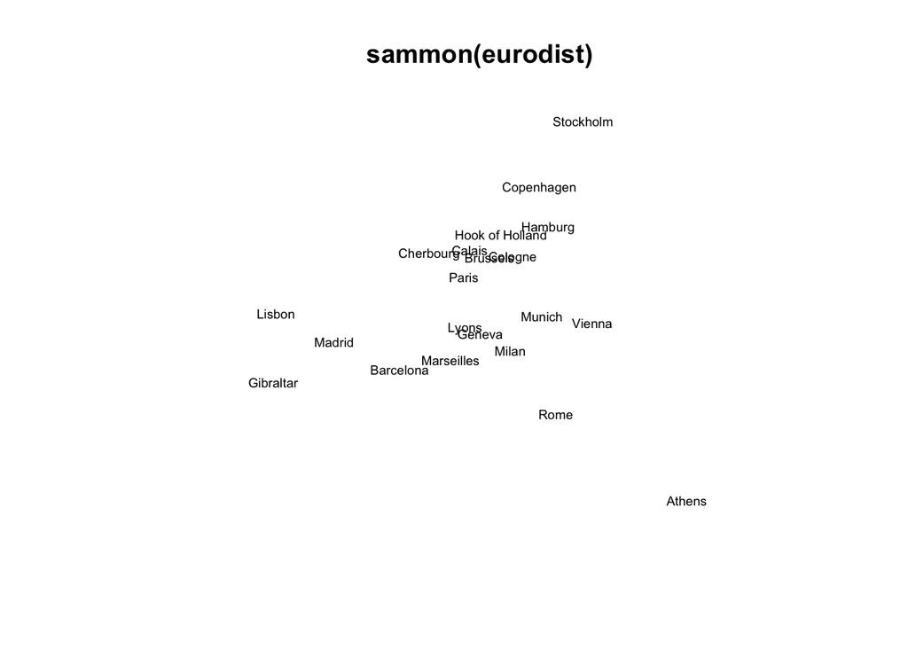

```r
x <- loc$points[, 1]
y <- -loc$points[, 2] # reflect so North is at the top
plot(x,y, type = "n", xlab = "", ylab = "", asp = 1, axes = FALSE,
     main = "sammon(eurodist)")
text(x,y, rownames(loc$points), cex = 0.6)
```

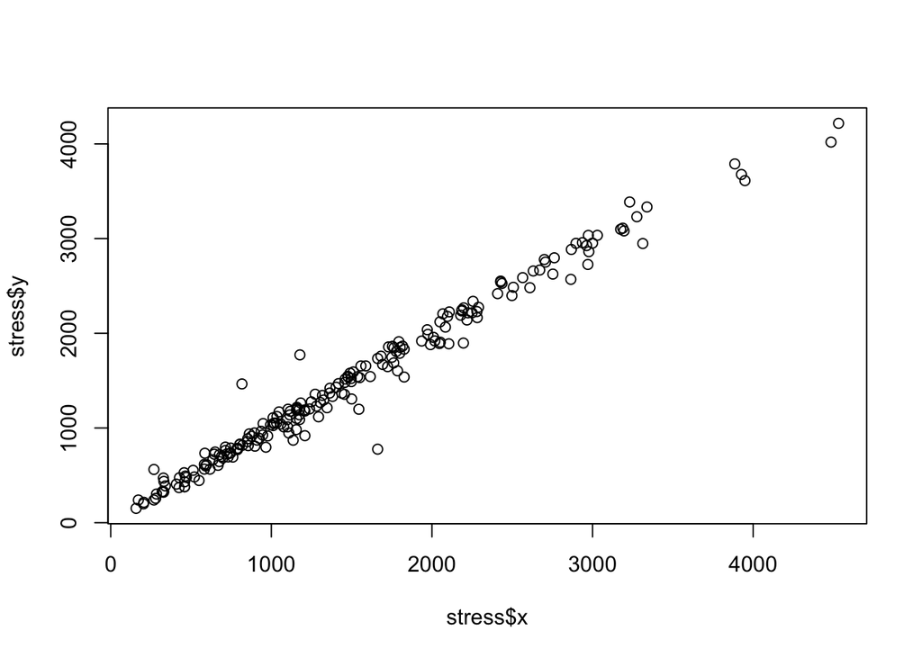

```r
stress <- Shepard(eurodist, loc$points)
plot(stress)
```

```r
loc <- isoMDS(eurodist)
```

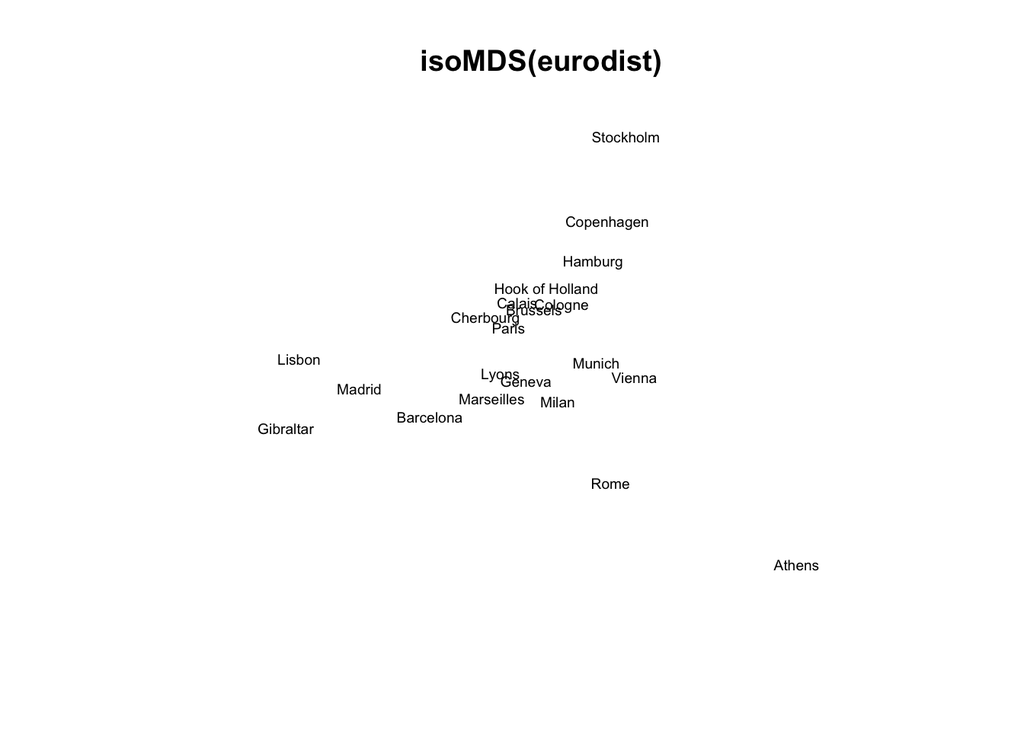

```r
x <- loc$points[, 1]
y <- -loc$points[, 2] # reflect so North is at the top
plot(x,y, type = "n", xlab = "", ylab = "", asp = 1, axes = FALSE,
     main = "isoMDS(eurodist)")
text(x,y, rownames(loc$points), cex = 0.6)
```

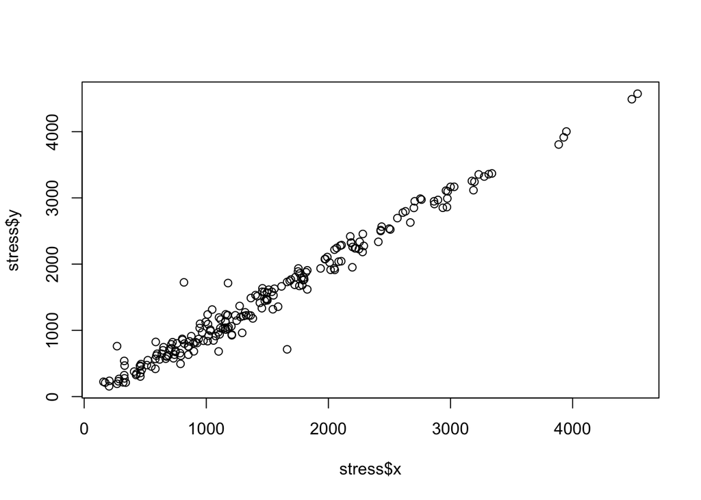

```r
stress <- Shepard(eurodist, loc$points)
plot(stress)
```